# Report Presentation

Liwei Wang

June 30 2020

This code is exactly for my undergraduate thesis (major in statistics).

### Abstract

From the perspective of classification problems and variable selection, this thesis attempts to identify key mutation genes that cause two groups of single-cell lesions. Based on the expression data of unbalanced, high-dimensional, zero-expansion with small sample single-cell RNA gene sequencing data, the following steps were taken for analysis. First, this thesis adopts the method of normal distribution test to pre-screen out genetic variables with excessive zero expansion and no biological significance. Further, this thesis uses the shrinkage and Logistics binary classification method, i.e, Lasso and its variants, to select key genetic variables. At the same time, this thesis chooses to use the synthetic sampling method, SMOTE, to generate new training data to improve the balance of previous unbalanced data, and effectively improve the AUC value of the classifiers and the variable selection results. After finding potential key genetic variables that significantly affect cytopathic changes, the candidate gene variables selected in this thesis were subjected to T-distribution mean hypothesis test and multiple hypothesis tests for secondary verification to obtain the final key gene results. Finally, this article refers to the background knowledge of biology and genes online, and explains the final results.

Keywords:

Unbalanced Data; SMOTE; Variable Selection on High-Dimensional Data; Lasso; Multiple Hypothesis Testing

### Data Loading

```r
########################################################

rm(list=ls())

path <- getwd()
rawdata<-readRDS(paste(path, "/immature_neutrophil.rds", sep=""))

condition<-rawdata[['condition']]
condition<-data.frame(condition)
data<-data.frame(rawdata[['data']])

data<-data.frame(t(data))
condition<-condition$condition
data<-cbind(condition,data)

########################################################

Sum<-apply(data[,-1], 1, sum)
Mean<-apply(data[,-1], 1, mean)
Std<-apply(data[,-1], 1, sd)
Median<-apply(data[,-1], 1, median)
datadiscribe<-cbind(data,Sum,Mean,Std,Median)
head(datadiscribe[,(ncol(datadiscribe)-3):ncol(datadiscribe)])
```

```
##                           Sum      Mean       Std Median
## CATGCCTA_ATCA_ACCTGT 2671.732 0.1578478 0.4280808      0
## CATGCCTA_ATCA_TGTCTT 2637.746 0.1558399 0.4232782      0
## GCTCAGGA_ATCA_TGTCTT 3008.220 0.1777277 0.4386367      0
## TTCTGCCT_CTAC_CTGGTC 2691.990 0.1590447 0.4266532      0
## TTCTGCCT_CTAC_TGTTAC 2438.159 0.1440481 0.4179588      0
## CATGCCTA_TGAT_TGCGGC 2510.946 0.1483485 0.4193600      0
```

```r
sum(datadiscribe$condition=='sham')
```

```
## [1] 18
```

```r
sum(datadiscribe$condition=='CLP')
```

```
## [1] 402
```

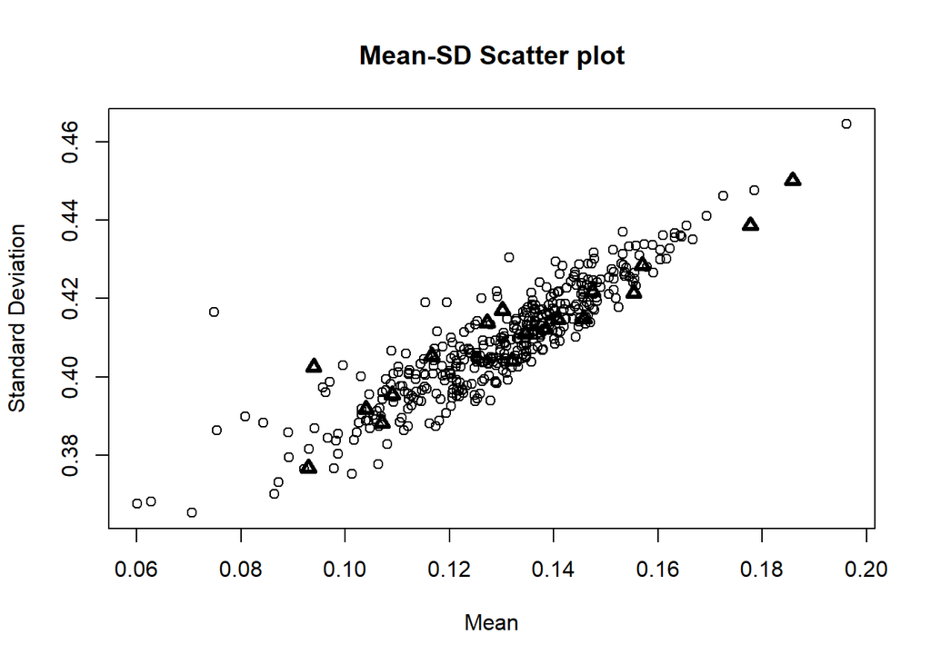

```r
plot(Mean,Std,pch=ifelse(factor(condition)=="sham",2, 1),col=
       'black',lty=1,lwd=ifelse(factor(condition)=="sham",3, 1),
     ylab='Standard Deviation', main='Mean-SD Scatter plot')
```

```r
##############

# Check No missing value

hang<-which(rowSums(is.na(data)) > 0)
hang
```

```
## named integer(0)
```